# Statistics: The Science of Decisions Project Instructions

## Stroop Task Analysis

```
Analysis will answer the following questions

1. What is our independent variable? What is our dependent variable?
2. What is an appropriate set of hypotheses for this task? What kind of statistical test do you expect to perform? Justify your choices.
3. Report some descriptive statistics regarding this dataset. Include at least one measure of central tendency and at least one measure of variability.
4. Provide one or two visualizations that show the distribution of the sample data. Write one or two sentences noting what you observe about the plot or plots.
5. Now, perform the statistical test and report your results. What is your confidence level and your critical statistic value? Do you reject the null hypothesis or fail to reject it? Come to a conclusion in terms of the experiment task. Did the results match up with your expectations?
6. Optional: What do you think is responsible for the effects observed? Can you think of an alternative or similar task that would result in a similar effect? Some research about the problem will be helpful for thinking about these two questions!
```

## 1. Independent and Dependent Variables

#### Independent Variable - The congruence of color and text

#### Dependent Variable - The amount of time(in seconds) it takes to read the text

## 2. Hypothesis and statistical test

H<sub>0</sub> ( μi - μc = 0 ): There is no statistical difference in reading congruent and incongruent text

H<sub>1</sub> ( μi - μc ≠ 0 ): There is a statistical difference in reading congruent and incongruent text

I will use A T-Test to determine if the difference in sample means could occur by chance. The correlation I am trying to prove is between two variables which are dependent. For this reason I will conduct a paired T-Test. A two sample t-test, an alternative means of analysis, would be less powerful as it would consider the two variables indepenedent. I have decided to use a two sided test to determine only if there is a relationship, and not the direction of the relationship. I am doing this because I want to prove that there is a relationship, and do not want to risk the possibility of misjudging this relationship.

## 3. Descriptive Statistics

#### Read data from CSV

```python
import os
path = os.getcwd()
import pandas
df = pandas.read_csv(path + '/stroopdata.csv')
print df
```

```
    Congruent  Incongruent
0      12.079       19.278
1      16.791       18.741
2       9.564       21.214
3       8.630       15.687
4      14.669       22.803
5      12.238       20.878
6      14.692       24.572
7       8.987       17.394
8       9.401       20.762
9      14.480       26.282
10     22.328       24.524
11     15.298       18.644
12     15.073       17.510
13     16.929       20.330
14     18.200       35.255
15     12.130       22.158
16     18.495       25.139
17     10.639       20.429
18     11.344       17.425
19     12.369       34.288
20     12.944       23.894
21     14.233       17.960
22     19.710       22.058
23     16.004       21.157
```

#### calculate descriptive statistics

```python
print df.describe()
```

```
       Congruent  Incongruent
count  24.000000    24.000000
mean   14.051125    22.015917
std     3.559358     4.797057
min     8.630000    15.687000
25%    11.895250    18.716750
50%    14.356500    21.017500
75%    16.200750    24.051500
max    22.328000    35.255000
```

## 4. Visualization of data distribution

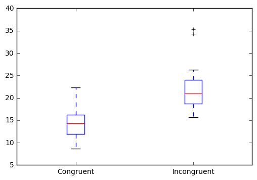

```python
%matplotlib inline //
df.plot.box()
```

## 5. Statistical Test of data

```python
from scipy.stats import ttest_rel
t_test = ttest_rel(df['Incongruent'],df['Congruent'])

print "T-Score: "+str(t_test.statistic)
print "pvalue: " + str(t_test.pvalue)
```

[output not shown]

#### Alpha = .001 & df = 23 : T-Critical = 3.768

T-score > T-Critical P-Value< Alpha

We must reject H<sub>0</sub> and accept H<sub>1</sub> that there is a significate difference in time (in seconds) it takes to read incongruent text.